# Fraud detect

Diego de Lima

March 29th, 2019

## Loading the packages

```r
library(data.table)
library(dplyr)
library(ggplot2)
library(lubridate)
library(gridExtra)
library(rlang)
library(randomForest)
library(caret)
library(ROSE)
```

## Loading the dataset

```r
train_sample <- fread('train_sample.csv') # dataset for training
```

Checking if there are missing values

```r
if(nrow(train_sample) !=  nrow(na.omit(train_sample))){
  print("One or more missing values were found")
}else{
  print("No missing values were found")
}
```

```
## [1] "No missing values were found"
```

## DATA EXPLORATION

**Premises:**  
1 - Variables which a high number of downloads have the potential to be strategical;  
2 - Being part of the most downloads and having a high rate of download, these variables will be suggested as strategical for probably having a strong conection with the success;  
3 - Strategical variables are important to be put in details, to bring up possible patterns and be explored in a trying to get betters results. (This exploration can’t be done with this dataset)

**Checking the importance to keep attributed_time in the data set**  
Assuming that attributed_time is filled only if is_attributed is setted with 1, the count of occurrences should return 0 if it’s OK. Otherwise, if the return is more than 0, there are inconsistences.

```r
count(train_sample %>%
        select(attributed_time, is_attributed) %>%
        filter(attributed_time != '' & is_attributed == 0))
```

```
## # A tibble: 1 x 1
##       n
##   <int>
## 1     0
```

As expected, the return was 0. So, it’s being considered redundant to work with both variables.

**Verifying the difference in days, between the date of click, and the date of the download**  
Assuming that, to consider the download as consequence of the advertising, the interval in days between the click on the ad and the start of the download has to be less than 1 day.  
So, if there aren’t intervals over 1 day, it’s possible to consider either attributed_time or click_time to make analysis regarding time.

```r
# click_time to make analysis regarding time.
if(count(train_sample %>%
         select(attributed_time, click_time) %>%
         filter(attributed_time != '') %>%
         mutate(difference = as.Date(attributed_time) - as.Date(click_time)) %>%
         filter(difference > 1)) > 0){
  print("The interval between de click and the download aren't connected")
} else {
  print('The interval is irrelevant')
}
```

```
## [1] "The interval is irrelevant"
```

As expected, the interval is irrelevant. So, at this point, attributed_time will be discarded.

```r
colnames(train_sample)
```

```
## [1] "ip"              "app"             "device"          "os"
## [5] "channel"         "click_time"      "attributed_time" "is_attributed"
```

```r
train_sample <- train_sample[, -7]
```

The variable IP should represent the id of the connection, what could be the id of a user, or a network.  
**A premise for IP:** if there are only unique values, so it should not be representative to explore. On the other hand, it should be included in other analysis.

```r
nrow(data.frame(table(train_sample$ip)) %>% filter(Freq > 1) %>% select(Freq))
```

```
## [1] 17434
```

As established before, with 17.434 occurencies of two or more clicks, it may be kept at this point.

## ANALYSIS OF DOWNLOAD RATES ALONG PERIODS OF DAY

Data set with the date and status of the download

```r
period_download <- train_sample %>% select(click_time, is_attributed)

# hour_download to analyse the download rate along the day
hour_download <- period_download %>%
  mutate(hour = sapply(click_time, hour))
```

**Clustering the periods of the day**  
from 00:00 to 07:59 am = 1  
from 08:00 to 04:59 pm = 2  
from 5:00pm to 11:59 pm = 3

```r
set_period <- function(x){
  if(x <= 7){
    return(1)
  } else if (x <= 16){
    return(2)
  } else {
    return(3)
  }
}

# period_download to analyse the download rate along the periods of the day
period_download <- period_download %>% mutate(period = sapply(hour(click_time), set_period))

# is_attributed's being considered as numeric to calculate the rate of download
period_download$is_attributed <- as.numeric(period_download$is_attributed)
str(period_download)
```

```
## 'data.frame':    100000 obs. of  3 variables:
##  $ click_time   : chr  "2017-11-07 09:30:38" "2017-11-07 13:40:27" "2017-11-07 18:05:24" "2017-11-07 04:58:08" ...
##  $ is_attributed: num  0 0 0 0 0 0 0 0 0 0 ...
##  $ period       : num  2 2 3 1 2 1 1 2 2 2 ...
```

Calculating the download rate by period

```r
period_download <- distinct(period_download %>%
                              group_by(period) %>%
                              mutate(
                                total_clicks = n(),
                                total_downloads = sum(is_attributed),
                                download_rate = (total_downloads / total_clicks) * 100
                              ) %>%
                              select(period, download_rate), period, .keep_all = TRUE)
```

Setting hour and period as factor

```r
period_download$period <- as.factor(period_download$period)
```

Plot of download rate by period of the day

```r
period_plot <- ggplot(period_download) +
  geom_col(aes(period, download_rate), fill = 'lightblue', color = 'darkblue', alpha = 0.7) +
  ggtitle('DOWNLOAD RATE BY PERIOD OF THE DAY') +
  xlab('Period') +
  ylab('Download Rate') +
  theme(plot.title = element_text(hjust = 0.5, vjust = 0.5, face = 'bold'))

# is_attributed's being considered as numeric to calculate the rate of download
hour_download$is_attributed <- as.numeric(hour_download$is_attributed)
str(hour_download)
```

```
## 'data.frame':    100000 obs. of  3 variables:
##  $ click_time   : chr  "2017-11-07 09:30:38" "2017-11-07 13:40:27" "2017-11-07 18:05:24" "2017-11-07 04:58:08" ...
##  $ is_attributed: num  0 0 0 0 0 0 0 0 0 0 ...
##  $ hour         : Named int  9 13 18 4 9 1 1 10 9 12 ...
##   ..- attr(*, "names")= chr  "2017-11-07 09:30:38" "2017-11-07 13:40:27" "2017-11-07 18:05:24" "2017-11-07 04:58:08" ...
```

Calculating the download rate by hour

```r
hour_download <- distinct(hour_download %>%
                            group_by(hour) %>%
                            mutate(
                              total_clicks = n(),
                              total_downloads = sum(is_attributed),
                              download_rate = (total_downloads / total_clicks) * 100,
                              period = sapply(hour, set_period)
                            ) %>%
                            select(hour, download_rate, period), hour, .keep_all = TRUE)
```

Setting hour and period as factors

```r
hour_download$hour <- as.factor(hour_download$hour)
hour_download$period <- as.factor(hour_download$period)
```

Plot of download rate per hour

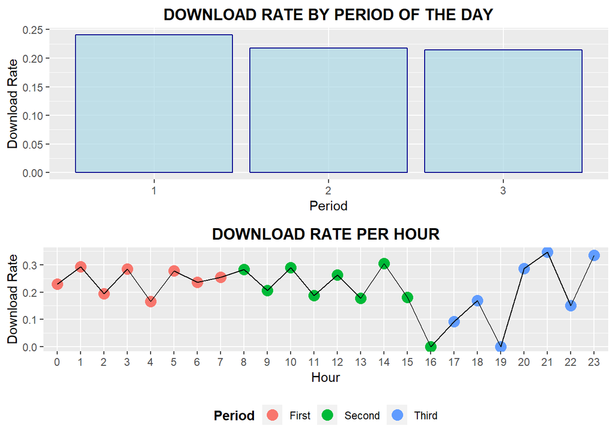

```r
hour_plot <- ggplot(hour_download, aes(hour, download_rate, group = 1)) +
  geom_point(aes(color = factor(period, labels = c('First', 'Second', 'Third'))), size = 4) +
  theme(legend.position = 'bottom') +
  labs(color = 'Period') +
  geom_line() +
  ggtitle('DOWNLOAD RATE PER HOUR') +
  xlab('Hour') +
  ylab('Download Rate') +
  theme(plot.title = element_text(hjust = 0.5, vjust = 0.5, face = 'bold'),
        legend.title = element_text(face = 'bold'))

grid.arrange(period_plot, hour_plot, nrow = 2)
```

## FIRST CONCLUSIONS

**As shown in the plots, the first period has the highest rate of download with a shorter variation, even though there’s not much difference from others, which turns it difficult to make explicit conclusions.**

Since there are few dates and few download variation rate along the day, it’s being considered only the hours of the click as a time variable.

```r
train_sample <- train_sample %>% mutate(hour = sapply(click_time, hour)) %>% select(-click_time)
```

## ADDITIONAL ANALYSIS

**Calculating the download rate, frequency of download and cumulative frequency of download by app, device, os and channel**

Function to capitalize the first letter

```r
cap_first <- function(x) {
  txt <- strsplit(x, " ")[[1]]
  paste(toupper(substring(txt, 1,1)), substring(txt, 2),
        sep="", collapse=" ")
}
```

Function to calculate and plot the analysis

```r
down_rate <- function(variable){
  target <- parse_quosure(variable) # quo
  df <- data.frame(train_sample %>% select(!!target, is_attributed))
  number <- length(unique(df[, variable])) # calculating the number of the target uniques

  # Calculating the total of clicks and downloads, and download rate
  df <- distinct(df %>%
                   group_by(!!target) %>%
                   mutate(
                     total_clicks = n(),
                     total_downloaded = sum(is_attributed),
                     download_rate = (total_downloaded / total_clicks) * 100
                   ) %>%
                   select(!!target, total_clicks, total_downloaded, download_rate))

  # Reordering the data set by total_clicks
  setorder(df, -total_downloaded)

  # Calculating the cumulative clicks and cumulative frequency of clicks
  df <- df %>% transform(download_cum = cumsum(total_downloaded), download_freq = prop.table(total_downloaded))
  df <- df %>% transform(down_freq_cum = cumsum(download_freq)) %>%
    select(!!target, total_clicks, total_downloaded, download_rate, down_freq_cum)

  # Plotting targets which represents 80% of the download total
  df[, variable] <- as.factor(df[, variable])
  if(nrow(df %>% filter(down_freq_cum <= 0.8)) <= 1){
    df <- df[1:2,]
  } else if (nrow(df %>% filter(down_freq_cum <= 0.8)) > 20){
    df <- df[1:20,]
  } else{
    df <- df %>% filter(down_freq_cum <= 0.8)
  }
  cumulative_freq <- max(df$down_freq_cum)

  ggplot(df) +
    geom_col(aes(!!target, download_rate), fill = 'lightblue', color = 'darkblue', alpha = 0.7) +
    coord_flip() +
    theme(legend.position = 'bottom') +
    ggtitle(paste(
      'DOWNLOAD RATE OF THE ',
      toupper(variable),
      ' WHICH SUM ABOUT ',
      round(cumulative_freq * 100),
      '% OF THE DOWNLOADS'
      , sep = '')) +
    xlab(cap_first(variable)) +
    ylab('Download Rate') +
    labs(subtitle = paste(
      round((nrow(df) / number)*100, 2),
      '% of the ',
      variable,
      's represent about ',
      round(cumulative_freq * 100),
      '% of the downloads',
      sep = '')) +
    geom_text(
      data = df,
      aes(x = !!target, y = download_rate, label = paste(round(download_rate, 2), '%', sep = '')),
      hjust = -0.1) +
    theme(plot.title = element_text(hjust = 0.5, vjust = 0.5, face = 'bold'),
          plot.subtitle = element_text(hjust = 0.5, vjust = 0.5)) +
    ylim(0, 100)
}
```

**Analysis**

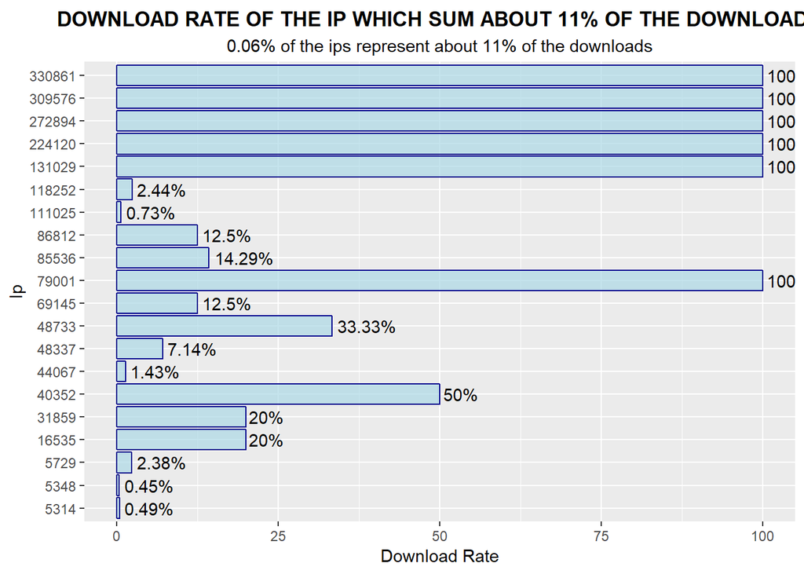

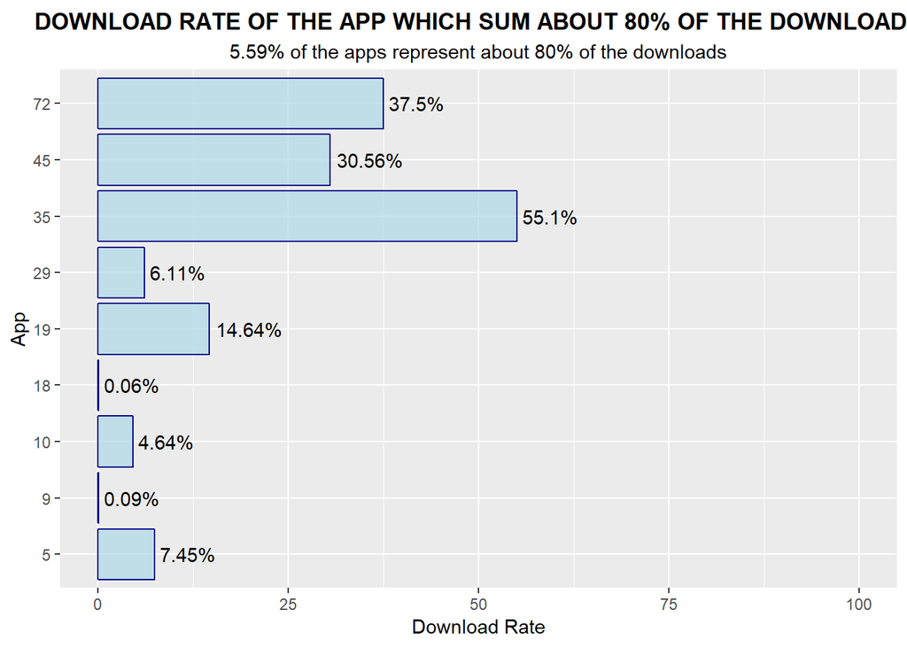

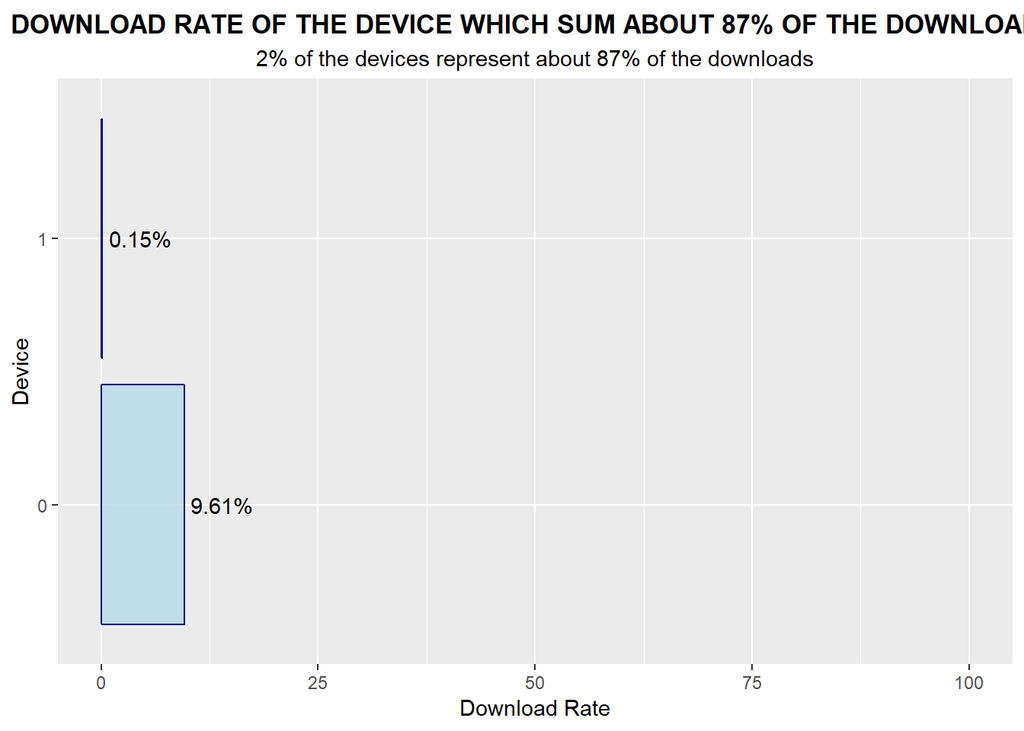

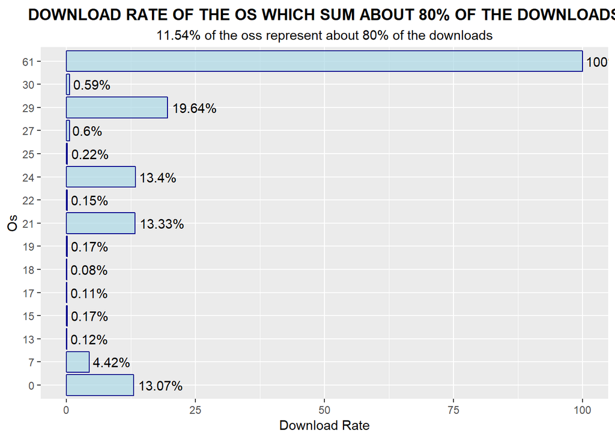

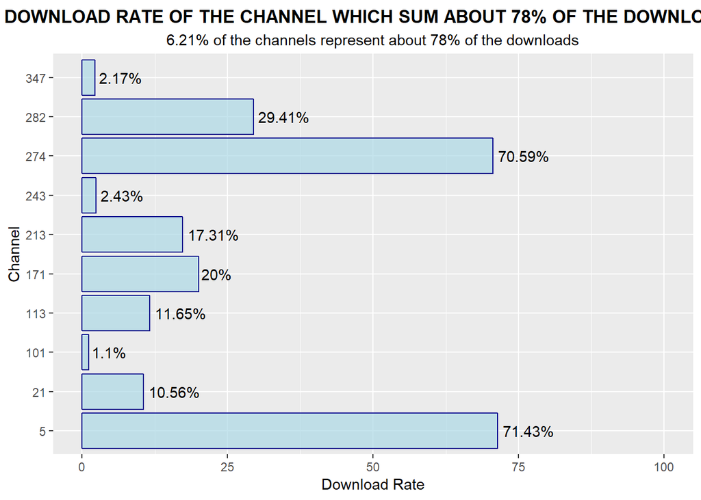

```r
variables <- c('ip', 'app', 'device', 'os', 'channel')
lapply(variables, down_rate)
```

## CONCLUSIONS

Function to calculate the % of download by variable

```r
calc_perc <- function(variable, value){
  target <- parse_quosure(variable) # quo
  perc <- round(
    (sum(train_sample %>%
           filter(!!target == value) %>%
           select(is_attributed)) / sum(train_sample$is_attributed) * 100)
    , 2)
  return(perc)
}
```

## IP

**Six IPs between the 11% most downloadable have 100% of download rate: 330861, 309576, 272894, 224120, 131029, 79001**

```r
calc_perc('ip', '330861')
```

```
## [1] 0.44
```

```r
calc_perc('ip', '309576')
```

```
## [1] 0.44
```

```r
calc_perc('ip', '272894')
```

```
## [1] 0.44
```

```r
calc_perc('ip', '224120')
```

```
## [1] 0.44
```

```r
calc_perc('ip', '131029')
```

```
## [1] 0.44
```

```r
calc_perc('ip', '79001')
```

```
## [1] 0.44
```

**With 2.64% of the download total, these IPs could be more detailed trying to bring up some pattern and be strategic used to improve the ads.**

## APP

**Between the APPs which represent about 80% of the downloads, the only which may be considered relevan for strategic actions is the 35, with 55.1% of download rate.**

This app represents 11.89% of the total of downloads

```r
calc_perc('app', '35')
```

```
## [1] 11.89
```

## DEVICE

**Two devices represent the total of 87% of the downloads. But, they shouldn’t be considered strategically because of their low rate.**

## OS

**Between the OSs which represent about 80% of the downloads, the 61 could be considered strategicaly important once it has 100% of download rate. However, they represent only 1.76% of the downloads, which may be irrelevant.**

```r
calc_perc('os', '61')
```

```
## [1] 1.76
```

## CHANNEL

**Two channels are significant with 70.59% and 71.43% of download rate respectively: 274 and 5.** Together they represent 7.49% of the downloads

```r
calc_perc('channel', '274')
```

```
## [1] 5.29
```

```r
calc_perc('channel', '5')
```

```
## [1] 2.2
```

## GENERAL

**Although there are features that can be strategic, alone they may be irrelevant. On the other hand, would be important to explore them with more details to check if it’s possible to realize their strenghs and share them to other features.**

## BUILDING THE MODEL

Once the problem nature is a binary classification, the possible results must be balanced to reproduce a good performance for both one.

```r
distribution <- data.frame(table(train_sample$is_attributed))
distribution <- distribution %>% mutate (perc = round((Freq / sum(Freq) * 100), 2))
```

Checking the results distribution

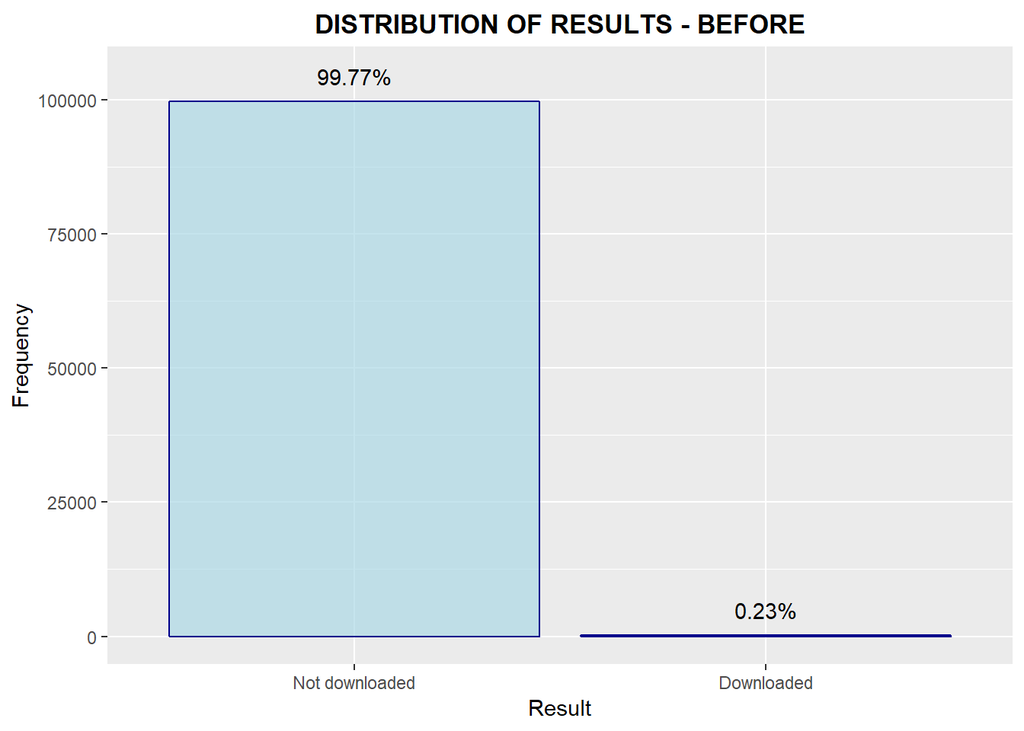

```r
unballanced <- ggplot(distribution) +
  geom_col(aes(x = Var1, y = Freq), fill = 'lightblue', color = 'darkblue', alpha = 0.7) +
  ggtitle('DISTRIBUTION OF RESULTS - BEFORE') +
  geom_text(data = distribution, aes(x = Var1, y = Freq, label = paste(perc, "%", sep='')), vjust = -1) +
  xlab('Result') +
  ylab('Frequency') +
  ylim(0, max(distribution$Freq) * 1.05) +
  theme(plot.title = element_text(hjust = 0.5, vjust = 0.5, face = 'bold')) +
  scale_x_discrete(labels = c('0' = 'Not downloaded', '1' = 'Downloaded'))


grid.arrange(unballanced, nrow = 1)
```

**As shown in the plot, the results aren’t balanced. So in case of the first model don’t be able to predict both, downloaded and not downloaded occurences, this information will must be considered.**

*Saving the original data set into a new set to train the model*

```r
new_sample <- train_sample
```

**Checking the format of the variables:**  
ip, app, device, os, channel, hour and is_attributed are categorical variables. But, the uniques known variables are: is_attributed and hour

```r
new_sample <- data.frame(new_sample)
categorical_train <- c('is_attributed', 'hour')
new_sample[, categorical_train] <- lapply(new_sample[, categorical_train], factor)
```

**Spliting the dataset into train_set and test_set with a ratio of 70% / 30% for train / test respectively**  
Setting seed to reproduce the same values

```r
set.seed(50)
values <- c(sample.int(nrow(new_sample), 0.7*nrow(new_sample), replace = FALSE))
train_set_1 <- new_sample[values, ]
test_set_1 <- new_sample[-values, ]
```

## Training and evaluating the performance of the model

```r
model_1 = randomForest(is_attributed ~ ., data = train_set_1, ntree = 10, nodesize = 10)
prediction_1 = data.frame(obs = test_set_1$is_attributed,
                      pred = predict(model_1, newdata = test_set_1))

model_1
```

```
##
## Call:
##  randomForest(formula = is_attributed ~ ., data = train_set_1,      ntree = 10, nodesize = 10)
##                Type of random forest: classification
##                      Number of trees: 10
## No. of variables tried at each split: 2
##
##         OOB estimate of  error rate: 0.26%
## Confusion matrix:
##       0  1  class.error
## 0 69085 37 0.0005352854
## 1   141 18 0.8867924528
```

**The first model returns a low error rate, but with a FALSE NEGATIVE error by 88.67%**

```r
confusionMatrix(prediction_1$obs, prediction_1$pred)
```

```
## Confusion Matrix and Statistics
##
##           Reference
## Prediction     0     1
##          0 29931     3
##          1    62     4
##
##                Accuracy : 0.9978
##                  95% CI : (0.9972, 0.9983)
##     No Information Rate : 0.9998
##     P-Value [Acc > NIR] : 1
##
##                   Kappa : 0.1092
##
##  Mcnemar's Test P-Value : 6.291e-13
##
##             Sensitivity : 0.99793
##             Specificity : 0.57143
##          Pos Pred Value : 0.99990
##          Neg Pred Value : 0.06061
##              Prevalence : 0.99977
##          Detection Rate : 0.99770
##    Detection Prevalence : 0.99780
##       Balanced Accuracy : 0.78468
##
##        'Positive' Class : 0
##
```

**Although the Accuracy of testing the model with de test_set reaches 99.78%, the result of False Negative represents a low performance, as previous expected.**  
**So, the first trying to improve the general performance, is ballancing the results of the data set.**

```r
over_new_sample <- new_sample

over_new_sample <- ovun.sample(is_attributed ~ .,
                               data = new_sample,
                               method = "over",
                               N = nrow(new_sample) + nrow(new_sample %>% filter(is_attributed == 0)))$data

distribution_over <- data.frame(table(over_new_sample$is_attributed))
distribution_over <- distribution_over %>% mutate (perc = round((Freq / sum(Freq) * 100), 2))
```

Checking the results distribution

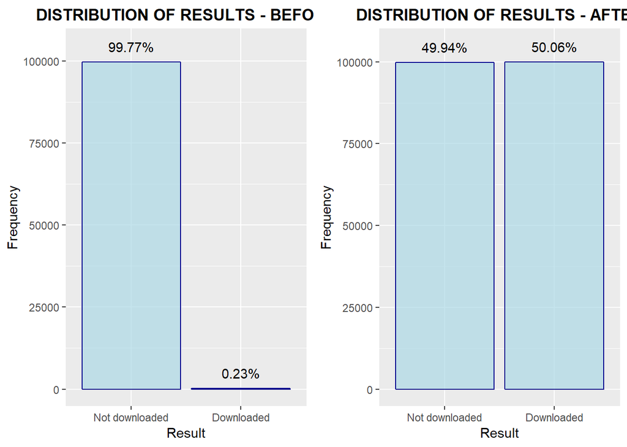

```r
ballanced <- ggplot(distribution_over) +
  geom_col(aes(x = Var1, y = Freq), fill = 'lightblue', color = 'darkblue', alpha = 0.7) +
  ggtitle('DISTRIBUTION OF RESULTS - AFTER') +
  geom_text(data = distribution_over, aes(x = Var1, y = Freq, label = paste(perc, "%", sep='')), vjust = -1) +
  xlab('Result') +
  ylab('Frequency') +
  ylim(0, max(distribution_over$Freq) * 1.05) +
  theme(plot.title = element_text(hjust = 0.5, vjust = 0.5, face = 'bold')) +
  scale_x_discrete(labels = c('0' = 'Not downloaded', '1' = 'Downloaded'))

grid.arrange(unballanced, ballanced, ncol = 2)
```

**Spliting the data set into train_set and test_set with a ratio of 70% / 30% for train / test respectively**  
Setting seed to reproduce the same values

```r
set.seed(50)
values <- c(sample.int(nrow(over_new_sample), 0.7*nrow(over_new_sample), replace = FALSE))
train_set_2 <- over_new_sample[values, ]
test_set_2 <- over_new_sample[-values, ]
```

## Training and evaluating the performance of the model

```r
model_2 = randomForest(is_attributed ~ ., data = train_set_2, ntree = 10, nodesize = 10)
prediction_2 = data.frame(obs = test_set_2$is_attributed,
                      pred = predict(model_2, newdata = test_set_2))

model_2
```

```
##
## Call:
##  randomForest(formula = is_attributed ~ ., data = train_set_2,      ntree = 10, nodesize = 10)
##                Type of random forest: classification
##                      Number of trees: 10
## No. of variables tried at each split: 2
##
##         OOB estimate of  error rate: 0.15%
## Confusion matrix:
##       0     1 class.error
## 0 68768   214 0.003102259
## 1     0 69425 0.000000000
```

**With the balanced data set, the error rate and the FALSE NEGATIVE were reduced as expected, on the other hand there was an increasement in FALSE POSITIVE.**

```r
confusionMatrix(prediction_2$obs, prediction_2$pred)
```

```
## Confusion Matrix and Statistics
##
##           Reference
## Prediction     0     1
##          0 29995    74
##          1     0 29863
##
##                Accuracy : 0.9988
##                  95% CI : (0.9985, 0.999)
##     No Information Rate : 0.5005
##     P-Value [Acc > NIR] : < 2.2e-16
##
##                   Kappa : 0.9975
##
##  Mcnemar's Test P-Value : < 2.2e-16
##
##             Sensitivity : 1.0000
##             Specificity : 0.9975
##          Pos Pred Value : 0.9975
##          Neg Pred Value : 1.0000
##              Prevalence : 0.5005
##          Detection Rate : 0.5005
##    Detection Prevalence : 0.5017
##       Balanced Accuracy : 0.9988
##
##        'Positive' Class : 0
##
```

**With an accuracy of 99.88% testing with the test_set, this model is even better than the first.**  
Trying to reach a better performance for FALSE POSITIVE and FALSE NEGATIVE, it was tested the importance of the variables.

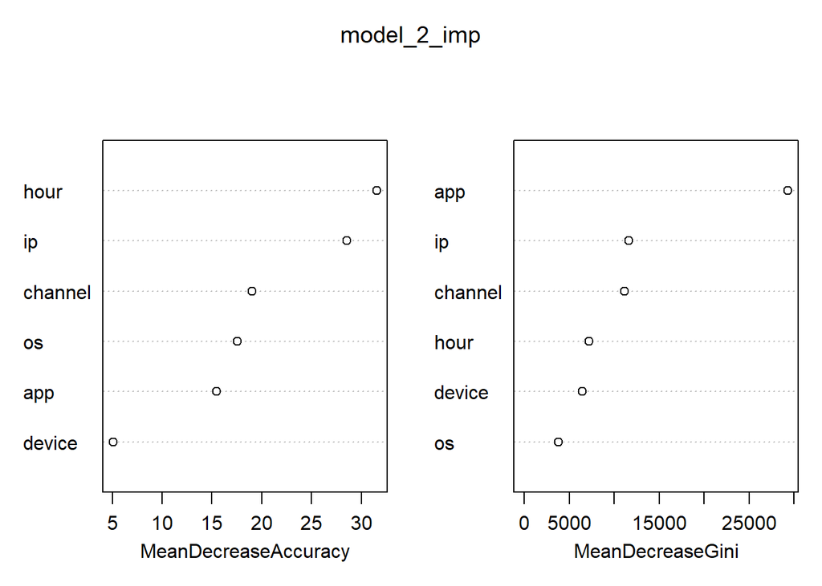

```r
model_2_imp <- randomForest(is_attributed ~ ., data = train_set_2, ntree = 10, nodesize = 10, importance = TRUE)
varImpPlot(model_2_imp)
```

**With device being the minus important in Mean Decrease Accuracy, and the second one in Mean Decrease Gini at this time this variable isn’t being considered for the third model.**

Setting seed to reproduce the same values

```r
set.seed(50)
values <- c(sample.int(nrow(over_new_sample), 0.7*nrow(over_new_sample), replace = FALSE))
train_set_3 <- over_new_sample[values, ]
colnames(train_set_3)
```

```
## [1] "ip"            "app"           "device"        "os"
## [5] "channel"       "is_attributed" "hour"
```

```r
train_set_3 <- train_set_3[, -3]
test_set_3 <- over_new_sample[-values, ]
test_set_3 <- test_set_3[, -3]
```

## Training and evaluating the performance of the model

```r
model_3 = randomForest(is_attributed ~ ., data = train_set_3, ntree = 10, nodesize = 10)
prediction_3 = data.frame(obs = test_set_3$is_attributed,
                          pred = predict(model_3, newdata = test_set_2))

model_3
```

```
##
## Call:
##  randomForest(formula = is_attributed ~ ., data = train_set_3,      ntree = 10, nodesize = 10)
##                Type of random forest: classification
##                      Number of trees: 10
## No. of variables tried at each split: 2
##
##         OOB estimate of  error rate: 0.12%
## Confusion matrix:
##       0     1 class.error
## 0 68839   160 0.002318874
## 1     0 69428 0.000000000
```

```r
confusionMatrix(prediction_3$obs, prediction_3$pred)
```

```
## Confusion Matrix and Statistics
##
##           Reference
## Prediction     0     1
##          0 30008    61
##          1     0 29863
##
##                Accuracy : 0.999
##                  95% CI : (0.9987, 0.9992)
##     No Information Rate : 0.5007
##     P-Value [Acc > NIR] : < 2.2e-16
##
##                   Kappa : 0.998
##
##  Mcnemar's Test P-Value : 1.564e-14
##
##             Sensitivity : 1.0000
##             Specificity : 0.9980
##          Pos Pred Value : 0.9980
##          Neg Pred Value : 1.0000
##              Prevalence : 0.5007
##          Detection Rate : 0.5007
##    Detection Prevalence : 0.5017
##       Balanced Accuracy : 0.9990
##
##        'Positive' Class : 0
##
```

## Final model description

**With an accuracy reaching 99.9% and a better ballance between FALSE POSTIVE and FALSE NEGATIVE, this model is quite better than the other two.**